# VS5 - Functions for Euclidean Geometry

Elvan Ceyhan

2023-12-18

```r
library(pcds)
library(plot3D)
```

# 1 Auxiliary Functions for Two and Three Dimensional Euclidean Geometry

We provide the equations for the $d-1$ dimensional hyper-planes and related geometric structures in $d$-dimensional Euclidean space for $d=2,3$. That is, we provide the equations of the lines, planes, and intersection points, etc. in $\mathbb R^2$ and $\mathbb R^3$. Some of these functions are used in the construction of proximity regions and the related PCDs hence are auxiliary functions in the construction of PCDs (see Ceyhan (2005) and Ceyhan (2010) for more details).

## 1.1 Geometric Structures in 2D Euclidean Space

The equation of the line and other related quantities like slope and intercept and the plot of the line are provided by the function `Line`. This function is different from the `line` function in the standard `stats` package in `R` in the sense that `Line(a,b,x)` fits the line passing through points `a` and `b` and returns various quantities related to this line (see below) and `x` is the vector of $x$-coordinates of the points on the line `Line(a,b,x)` (i.e., want the compute the $y$ coordinates of the points on the line `Line(a,b,x)` whose $x$-coordinates are given in the vector `x` while `line(a,b)` fits a straight line robustly whose $x$-coordinates are in vector `a` and $y$-coordinates are in vector `b`.

### 1.1.1 Equation of the Line Crossing two Distinct 2D Points

The function `Line` is an object of class `Lines` and has arguments `a,b,x` where

- `a,b`, 2D points that determine the straight line (i.e., through which the straight line passes) and
- `x`, a scalar or a vector of scalars representing the $x$-coordinates of the line.

Its `call` (with `lnAB` in the below script) just returns `Coefficients of the line (for the form: y = slope * x + intercept)`. Its `summary` returns the defining points, selected $x$ points (first row) and estimated $y$ points (second row) that fall on the line (first 6 or fewer), the equation of the line, and the coefficients of the line (i.e., the `slope` and `intercept`). The `plot` function (or `plot.Lines`) returns the plot of the line together with the defining points.

```r
A<-c(-1.22,-2.33); B<-c(2.55,3.75)

xr<-range(A,B);
xf<-(xr[2]-xr[1])*.1 #how far to go at the lower and upper ends in the x-coordinate
x<-seq(xr[1]-xf,xr[2]+xf,l=5)  #try also l=10, 20, or 100

lnAB<-Line(A,B,x)
lnAB
```

```
#> Call:
#> Line(a = A, b = B, x = x)
#>
#> Coefficients of the line (in the form: y = slope * x + intercept)
#>  1.6127321 -0.3624668
```

```r
summary(lnAB)
```

```
#> Call:
#> Line(a = A, b = B, x = x)
#>
#> Defining Points
#>    [,1]  [,2]
#> A -1.22 -2.33
#> B  2.55  3.75
#>
#> Selected x points (first row) and estimated y points (second row)
#>   that fall on the Line (first 6 or fewer are printed at each row)
#> -2.938 -1.114  0.710  2.534  4.358
#> -5.1006737 -2.1590504  0.7825729  3.7241963  6.6658196
#>
#> Equation of the Line Passing through two Distinct Points A and B
#> y=1.61273209549072x-0.362466843501326
#>
#> Coefficients (slope and intercept) of the line
#>      slope  intercept
#>  1.6127321 -0.3624668
```

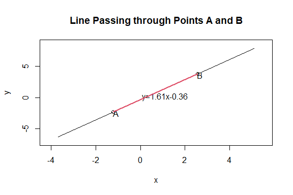

Figure 1.1: The line joining the points $A$ and $B$ in 2D space.

```r
plot(lnAB)
```

The difference of the function `Line` from the `line` function in the standard `stats` package in `R` is illustrated below.

```r
line(A,B)  #this takes vector A as the x points and vector B as the y points and fits the line
```

```
#>
#> Call:
#> line(A, B)
#>
#> Coefficients:
#> [1]   1.231  -1.081
```

```r
line(x,lnAB$y) #gives the same line as Line(A,B,x) above
```

```
#>
#> Call:
#> line(x, lnAB$y)
#>
#> Coefficients:
#> [1]  -0.3625   1.6127
```

```r
c(lnAB$intercept,lnAB$slope)
```

```
#>  intercept      slope
#> -0.3624668  1.6127321
```

The slope of the line joining two distinct 2D points `a` and `b` can be found by the `slope` function with arguments `a,b` which are as in the function `Line`.

```r
slope(A,B)
```

```
#> [1] 1.612732
```

### 1.1.2 Equation of the Line Crossing a Point and Parallel to the Line Crossing two Distinct 2D Points

The equation of the line crossing a point `p` parallel to the line segment joining two distinct 2D points `a` and `b` is provided by the function `paraline`. Other related quantities like slope and intercept and the plot of the line are also provided. The function `paraline` is an object of class `Lines` which takes arguments `p,a,b,x` where

- `a,b,x` are as in the function `Line` and
- `p` is a 2D point at which the parallel line to line segment joining `a` and `b` crosses.

Its `call`, `summary`, and `plot` are also as in `Line`.

```r
A<-c(1.1,1.2); B<-c(2.3,3.4); P<-c(.51,2.5)

pts<-rbind(A,B,P)
xr<-range(pts[,1])
xf<-(xr[2]-xr[1])*.25 #how far to go at the lower and upper ends in the x-coordinate
x<-seq(xr[1]-xf,xr[2]+xf,l=5)  #try also l=10, 20, or 100

plnAB<-paraline(P,A,B,x)
plnAB
```

```
#> Call:
#> paraline(p = P, a = A, b = B, x = x)
#>
#> Coefficients of the line (in the form: y = slope * x + intercept)
#>     slope intercept
#>  1.833333  1.565000
```

```r
summary(plnAB)
```

```
#> Call:
#> paraline(p = P, a = A, b = B, x = x)
#>
#> Defining Points
#>   [,1] [,2]
#> A 1.10  1.2
#> B 2.30  3.4
#> P 0.51  2.5
#>
#>  Selected x points (first row) and estimated y points (second row) that fall on the Line
#>       (first 6 or fewer are printed at each row)
#> [1] 0.06250 0.73375 1.40500 2.07625 2.74750
#> [1] 1.679583 2.910208 4.140833 5.371458 6.602083
#>
#> Equation of the Line Crossing Point P and Parallel to Line Segment [AB]
#> [1] "y=1.83333333333333x+1.565"
#>
#> Coefficients of the line (when the line is in the form: y = slope * x + intercept)
#> intercept     slope
#>  1.565000  1.833333
```

```r
plot(plnAB)
```

[output not shown]

### 1.1.3 Equation of the Line Crossing a Point and Perpendicular to the Line Crossing two Distinct 2D Points

The equation of the line crossing a point `p` perpendicular to the line segment joining two distinct 2D points `a` and `b` is provided by the function `perpline`. Other related quantities like slope and intercept and the plot of the line are also provided. The function `perpline` is an object of class `Lines` and has the same arguments as `paraline`. Its `call`, `summary`, and `plot` are as in `Line`. In the plot of the object, we use `asp=1` so that the lines are depicted correctly, i.e., as perpendicular to each other.

```r
A<-c(1.1,1.2); B<-c(2.3,3.4); P<-c(.51,2.5)

pts<-rbind(A,B,P)
xr<-range(pts[,1])
xf<-(xr[2]-xr[1])*.25 #how far to go at the lower and upper ends in the x-coordinate
x<-seq(xr[1]-xf,xr[2]+xf,l=5)  #try also l=10, 20, or 100

plnAB<-perpline(P,A,B,x)
plnAB
```

```
#> Call:
#> perpline(p = P, a = A, b = B, x = x)
#>
#> Coefficients of the line (in the form: y = slope * x + intercept)
#>      slope  intercept
#> -0.5454545  2.7781818
```

```r
summary(plnAB)
```

```
#> Call:
#> perpline(p = P, a = A, b = B, x = x)
#>
#> Defining Points
#>   [,1] [,2]
#> A 1.10  1.2
#> B 2.30  3.4
#> P 0.51  2.5
#>
#>  Selected x points (first row) and estimated y points (second row) that fall on the Line
#>       (first 6 or fewer are printed at each row)
#> [1] 0.06250 0.73375 1.40500 2.07625 2.74750
#> [1] 2.744091 2.377955 2.011818 1.645682 1.279545
#>
#> Equation of the Line Crossing Point P Perpendicular to Line Segment [AB]
#> [1] "y=-0.545454545454545x+2.77818181818182"
#>
#> Coefficients of the line (when the line is in the form: y = slope * x + intercept)
#>  intercept      slope
#>  2.7781818 -0.5454545
```

```r
plot(plnAB,asp=1)
```

[output not shown]

The point of intersection of two lines, where each line is defined by a pair of points, is provided by the function `intersect2lines`. The arguments of the functions are the four points `p1,q1,p2,q2`, where the first line is defined with the points `p1,q1`, and the second line is defined with the points `p2,q2`.

```r
A<-c(-1.22,-2.33); B<-c(2.55,3.75); C<-c(0,6); D<-c(3,-2)
ip<-intersect2lines(A,B,C,D)
ip
```

```
#> [1] 1.486767 2.035289
```

The angles to draw arcs between two line segments can be computed with the function `angle.str2end` which takes arguments `a,b,c,radian` where

- `a,b,c` three 2D points which represent the intersecting line segments $[ba]$ and $[bc]$.
- `radian`, a logical argument (default=`TRUE`). If `TRUE`, the smaller angle or counter-clockwise angle between the line segments $[ba]$ and $[bc]$ is provided in radians, else it is provided in degrees.

This function returns the output

- `small.arc.angles`, angles of $[ba]$ and $[bc]$ with the $x$-axis so that difference between them is the smaller angle between $[ba]$ and $[bc]$, and
- `ccw.arc.angles`, angles of $[ba]$ and $[bc]$ with the $x$-axis so that difference between them is the counter-clockwise angle between $[ba]$ and $[bc]$

The two pairs of angles in radians or degrees in the output of this function is used to draw arcs between two vectors or line segments for the `plotrix::draw.arc` function in the `plotrix` package. More specifically, these angles are used to draw AS proximity regions (for the circular parts, i.e., arc-slices inside the triangle), The angles are provided with respect to the $x$-axis in the coordinate system. The line segments are $[ba]$ and $[bc]$ for the arguments `a,b,c` of the function.

Below are the angles between line segments $BA$ and $BC$ first in radians and then in degrees.

```r
A<-c(.3,.2); B<-c(.6,.3); C<-c(1,1)

angle.str2end(A,B,C)
```

```
#> $small.arc.angles
#> [1] 1.051650 3.463343
#>
#> $ccw.arc.angles
#> [1] -2.819842  1.051650
```

```r
angle.str2end(A,B,C,radian=FALSE)
```

```
#> $small.arc.angles
#> [1]  60.25512 198.43495
#>
#> $ccw.arc.angles
#> [1] -161.56505   60.25512
```

```r
pts<-rbind(A,B,C)

Xp<-c(B[1]+max(abs(C[1]-B[1]),abs(A[1]-B[1])),0)

#plot of the line segments
ang.rad<-angle.str2end(A,B,C,radian=TRUE); ang.rad
ang.deg<-angle.str2end(A,B,C,radian=FALSE); ang.deg
ang.deg1<-ang.deg$s; ang.deg1
ang.deg2<-ang.deg$c; ang.deg2

rad<-min(Dist(A,B),Dist(B,C))

Xlim<-range(pts[,1],Xp[1],B+Xp,B[1]+c(+rad,-rad))
Ylim<-range(pts[,2],B[2]+c(+rad,-rad))
xd<-Xlim[2]-Xlim[1]
yd<-Ylim[2]-Ylim[1]

#plot for the counter-clockwise arc
plot(pts,pch=1,asp=1,xlab="x",ylab="y",xlim=Xlim+xd*c(-.05,.05),ylim=Ylim+yd*c(-.05,.05))
L<-rbind(B,B,B); R<-rbind(A,C,B+Xp)
segments(L[,1], L[,2], R[,1], R[,2], lty=2)
plotrix::draw.arc(B[1],B[2],radius=.3*rad,angle1=ang.rad$c[1],angle2=ang.rad$c[2])
plotrix::draw.arc(B[1],B[2],radius=.6*rad,angle1=0, angle2=ang.rad$s[1],lty=2,col=2)
plotrix::draw.arc(B[1],B[2],radius=.9*rad,angle1=0,angle2=ang.rad$s[2],col=3)
txt<-pts
text(txt+cbind(rep(xd*.02,nrow(txt)),rep(-xd*.02,nrow(txt))),c("A","B","C"))

text(rbind(B)+.5*rad*c(cos(mean(ang.rad$c)),sin(mean(ang.rad$c))),
     paste(abs(round(ang.deg2[2]-ang.deg2[1],2))," degrees",sep=""))
text(rbind(B)+.6*rad*c(cos(ang.rad$s[1]/2),sin(ang.rad$s[1]/2)),paste(round(ang.deg1[1],2)),col=2)
text(rbind(B)+.9*rad*c(cos(ang.rad$s[2]/2),sin(ang.rad$s[2]/2)),paste(round(ang.deg1[2],2)),col=3)
```

[output not shown]

The area of a polygon `h` in $\mathbb R^2$ is provided by the function `area.polygon` with the sole argument `h` which is a vector of $n$ 2D points, stacked row-wise, each row representing a vertex of the polygon, where $n$ is the number of vertices of the polygon.. Here the vertices of the polygon `h` must be provided in clockwise or counter-clockwise order, otherwise the function does not yield the area. Also, the polygon could be convex or non-convex. See (Weisstein (2019)).

```r
A<-c(0,0); B<-c(1,0); C<-c(0.5,.8);
Tr<-rbind(A,B,C);
area.polygon(Tr)
```

```
#> [1] 0.4
```

```r
A<-c(0,0); B<-c(1,0); C<-c(.7,.6); D<-c(0.3,.8);
h1<-rbind(A,B,C,D);  #try also h1<-rbind(A,B,D,C) or h1<-rbind(A,C,B,D) or h1<-rbind(A,D,C,B);
area.polygon(h1)
```

```
#> [1] 0.49
```

## 1.2 Various Distances and Related Functions

The proximity regions are based on *distances* or *dissimilarity measures* between points or between points and lines (or edges). So, we provide various functions that measure the distances between such geometric structures.

The distance from a point to a line defined by two points is provided by the function `dist.point2line` with arguments `p,a,b` where

- `p` is a 2D point, distance from `p` to the line passing through points `a` and `b` are to be computed.
- `a,b` are 2D points that determine the straight line (i.e., through which the straight line passes).

This function also returns the closest point on the line to the point `p`.

```r
dpl<-dist.point2line(P,A,B);
dpl
```

```
#> $distance
#> [1] 2.5
#>
#> $cl2p
#> [1] 0.51 0.00
```

The distance from a point `p` to a set `Yp` of finite cardinality where the set `Yp` is stored as a matrix is returned by the function `dist.point2set`. The function takes arguments `p,Yp` where

- `p`, a vector (i.e., a point in $\mathbb R^d$) and
- `Yp`, a set of $d$-dimensional points.

It returns the index and coordinates of the point in the set `Yp` closest to the point `p`.

```r
X1<-cbind(runif(10),runif(10))
dist.point2set(c(1,2),X1)
```

```
#> $distance
#> [1] 1.086349
#>
#> $ind.cl.point
#> [1] 3
#>
#> $closest.point
#> [1] 0.7933641 0.9334844
```

## 1.3 Geometric Structures in 3D Euclidean Space

There are more possibilities for the geometric structures in $\mathbb R^3$ compared to $\mathbb R^2$. In $\mathbb R^2$ only lines and their relationships exist, but in $\mathbb R^3$, in addition to the lines and their relationships, there are also planes, and relationships between lines and planes, and planes and planes.

### 1.3.1 Equation of the Line Crossing a Point Parallel to (i.e., in the Direction of) a Vector

The equation of the line crossing a point in the direction of a vector in the 3D space are provided by the function `Line3D`. If the option `dir.vec=TRUE` (which is the default) in `Line(p,v,t,dir.vec=T)`, the line crosses the point `p` in the direction of the vector `v` (i.e., parallel to the line joining the origin and `v`), otherwise, in `Line(p,v,t,dir.vec=FALSE)`,the line crosses `p` and is in the direction of the vector joining `p` and `v` (i.e., in direction of $v-r_0$).

The function `Line3D` is an object of class `Lines3D` and takes arguments `p,v,t,dir.vec` where

- `p`, a 3D point through which the straight line passes.
- `v`, a 3D vector which determines the direction of the straight line (i.e., the straight line would be parallel to this vector) if the `TRUE`, otherwise it is 3D point and $v-r_0$ determines the direction of the the straight line.
- `t`, a scalar or a vector of scalars representing the parameter of the coordinates of the line (for the form: $x=x_0 + A t$, $y=y_0 + B t$, and $z=z_0 + C t$ where $r_0=(x_0,y_0,z_0)$ and $v=(A,B,C)$ if `TRUE`, else $v-r_0=(A,B,C)$).
- `dir.vec`, a logical argument about `v`, if `TRUE` `v` is treated as a vector, else `v` is treated as a point and so the direction vector is taken to be $v-r_0$.

Its `call` (with `lnPQ3D` in the below script with the default option `dir.vec=TRUE`) just returns `Coefficients of the parameterized line passing through initial point P =(x0,y0,z0) in the direction of OQ =(A,B,C) (for the form: x=x0 + A*t, y=y0 + B*t, and z=z0 + C*t)`. Its `summary` returns the defining vectors, namely, `initial point` as viewed as a vector joining the origin and the point and `direction vector`, estimated $x$ points (first row), $y$ points (second row), and $z$ points (third row) (first 6 or fewer are printed at each row) , the equation of the line passing through point `p` in the direction of $OQ$ with $O$ representing the origin $(0,0,0)$ (i.e., parallel to $OQ$ ), and the coefficients of the parameterized line passing through initial point $P =(x_0,y_0,z_0)$ in the direction of $OQ =(A,B,C)$ (for the form: $x=x_0 + A\,t$, $y=y_0 + B\,t$, and $z=z_0 + C\,t$). The `plot` function (or `plot.Lines3D`) returns the plot of the line together with the defining points and vectors.

```r
P<-c(1,10,3); Q<-c(1,1,3);

vecs<-rbind(P,Q)

Line3D(P,Q,.1)
```

```
#> Call:
#> Line3D(p = P, v = Q, t = 0.1)
#>
#> Coefficients of the parameterized line passing through initial point P = (x0,y0,z0) in the direction of OQ = (A,B,C) (for the form: x=x0 + A*t, y=y0 + B*t, and z=z0 + C*t)
#>                  [,1] [,2] [,3]
#> initial point       1   10    3
#> direction vector    1    1    3
```

```r
Line3D(P,Q,.1,dir.vec=FALSE)
```

```
#> Call:
#> Line3D(p = P, v = Q, t = 0.1, dir.vec = FALSE)
#>
#> Coefficients of the parameterized line passing through initial point P = (x0,y0,z0) in the direction of PQ = (A,B,C) (for the form: x=x0 + A*t, y=y0 + B*t, and z=z0 + C*t)
#>                  [,1] [,2] [,3]
#> initial point       1   10    3
#> direction vector    0   -9    0
```

```r
tr<-range(vecs);
tf<-(tr[2]-tr[1])*.1 #how far to go at the lower and upper ends in the x-coordinate
tsq<-seq(-tf*10-tf,tf*10+tf,l=5)  #try also l=10, 20, or 100

lnPQ3D<-Line3D(P,Q,tsq)
lnPQ3D
```

```
#> Call:
#> Line3D(p = P, v = Q, t = tsq)
#>
#> Coefficients of the parameterized line passing through initial point P = (x0,y0,z0) in the direction of OQ = (A,B,C) (for the form: x=x0 + A*t, y=y0 + B*t, and z=z0 + C*t)
#>                  [,1] [,2] [,3]
#> initial point       1   10    3
#> direction vector    1    1    3
```

```r
summary(lnPQ3D)
```

```
#> Call:
#> Line3D(p = P, v = Q, t = tsq)
#>
#> Defining Vectors
#>                  [,1] [,2] [,3]
#> initial point       1   10    3
#> direction vector    1    1    3
#>
#>  Estimated x points (first row), y points (second row), and z points (third row)
#>    that fall on the Line
#>       (first 6 or fewer are printed at each row)
#> [1] -8.90 -3.95  1.00  5.95 10.90
#> [1]  0.10  5.05 10.00 14.95 19.90
#> [1] -26.70 -11.85   3.00  17.85  32.70
#>
#> Equation of the line passing through point P in the direction of OQ  with O representing the origin (0,0,0)
#>                    (i.e., parallel to OQ )
#>      [,1]
#> [1,] "x = 1 + t"
#> [2,] "y = 10 + t"
#> [3,] "z = 3 + 3t"
#>
#> Coefficients of the parameterized line passing through initial point P = (x0,y0,z0) in the direction of OQ = (A,B,C) (in the form: x = x0 + A*t, y = y0 + B*t, and z = z0 + C*t)
#>    [,1] [,2] [,3]
#> P     1   10    3
#> OQ    1    1    3
```

```r
plot(lnPQ3D)
```

[output not shown]

### 1.3.2 Equation of the Line Crossing a Point and Parallel to the Line Crossing two Distinct 3D Points

The equation of the line in 3D space crossing a point `p` and parallel to line joining 3D points `a` and `b` is returned by the function `paraline3D`. Other related quantities and the plot of the line are also provided. The function `paraline3D` is an object of class `Lines3D` and takes arguments `p,a,b,t` where

- `p`, a 3D point through which the straight line passes.
- `a,b`, 3D points which determine the straight line to which the line passing through point `p` would be parallel (i.e., $b-a$ determines the direction of the straight line passing through `p`).
- `t`, a scalar or a vector of scalars representing the parameter of the coordinates of the line (for the form: $x=x_0 + A t$, $y=y_0 + B t$, and $z=z_0 + C t$ where $p=(x_0,y_0,z_0)$ and $b-a=(A,B,C)$).

Its `call`, `summary`, and `plot` are as in `Line3D`.

```r
P<-c(1,10,4); Q<-c(1,1,3); R<-c(3,9,12)

vecs<-rbind(P,R-Q)
pts<-rbind(P,Q,R)
tr<-range(pts,vecs);
tf<-(tr[2]-tr[1])*.1 #how far to go at the lower and upper ends in the x-coordinate
tsq<-seq(-tf*10-tf,tf*10+tf,l=5)  #try also l=10, 20, or 100

pln3D<-paraline3D(P,Q,R,tsq)
pln3D
```

```
#> Call:
#> paraline3D(p = P, a = Q, b = R, t = tsq)
#>
#> Coefficients of the parameterized line passing through initial point P = (x0,y0,z0) in the direction of R - Q = (A,B,C) (for the form: x=x0 + A*t, y=y0 + B*t, and z=z0 + C*t)
#>                  [,1] [,2] [,3]
#> initial point       1   10    4
#> direction vector    2    8    9
```

```r
summary(pln3D)
```

```
#> Call:
#> paraline3D(p = P, a = Q, b = R, t = tsq)
#>
#> Defining Vectors
#>                  [,1] [,2] [,3]
#> initial point       1   10    4
#> direction vector    2    8    9
#>
#>  Estimated x points (first row), y points (second row), and z points (third row)
#>    that fall on the Line
#>       (first 6 or fewer are printed at each row)
#> [1] -23.2 -11.1   1.0  13.1  25.2
#> [1] -86.8 -38.4  10.0  58.4 106.8
#> [1] -104.90  -50.45    4.00   58.45  112.90
#>
#> Equation of the line passing through point P parallel to the line joining points Q and R
#>      [,1]
#> [1,] "x = 1 + 2t"
#> [2,] "y = 10 + 8t"
#> [3,] "z = 4 + 9t"
#>
#> Coefficients of the parameterized line passing through initial point P = (x0,y0,z0) in the direction of R - Q = (A,B,C) (in the form: x = x0 + A*t, y = y0 + B*t, and z = z0 + C*t)
#>       [,1] [,2] [,3]
#> P        1   10    4
#> R - Q    2    8    9
```

```r
plot(pln3D)
```

[output not shown]

### 1.3.3 Equation of the Plane Crossing three Distinct 3D Points

The equation of the plane crossing three distinct points in $\mathbb R^3$ is provided by the function `Plane`. Other related quantities and the plot of the plane are also provided. The function `Plane` is an object of class `Planes` and takes arguments `a,b,c,x,y` where

- `a,b,c` are 3D points that determine the plane (i.e., through which the plane is passing) and
- `x,y` are scalars or vectors of scalars representing the $x$- and $y$-coordinates of the plane.

Its `call` (with `plP123` in the below script) just returns `Coefficients of the Plane (in the form: z = A*x + B*y + C)`. Its `summary` returns the defining points, selected $x$ and $y$ points and estimated $z$ points — presented row-wise, respectively — that fall on the plane (first 6 or fewer are printed on each row), the equation of the plane passing through points `a`, `b`, and `c`, and the coefficients of the plane (in the form $z = A\,x + B\,y + C$). The `plot` function (or `plot.Planes`) returns the plot of the plane together with the defining points.

```r
P1<-c(1,10,3); P2<-c(1,1,3); P3<-c(3,9,12) #also try P2=c(2,2,3)

pts<-rbind(P1,P2,P3)
Plane(P1,P2,P3,.1,.2)
```

```
#> Call:
#> Plane(a = P1, b = P2, c = P3, x = 0.1, y = 0.2)
#>
#> Coefficients of the Plane (in the form: z = A*x + B*y + C):
#>    A    B    C
#>  4.5  0.0 -1.5
```

```r
xr<-range(pts[,1]); yr<-range(pts[,2])
xf<-(xr[2]-xr[1])*.1 #how far to go at the lower and upper ends in the x-coordinate
yf<-(yr[2]-yr[1])*.1 #how far to go at the lower and upper ends in the y-coordinate
x<-seq(xr[1]-xf,xr[2]+xf,l=3)  #try also l=10, 20, or 100
y<-seq(yr[1]-yf,yr[2]+yf,l=3)  #try also l=10, 20, or 100

plP123<-Plane(P1,P2,P3,x,y)
plP123
```

```
#> Call:
#> Plane(a = P1, b = P2, c = P3, x = x, y = y)
#>
#> Coefficients of the Plane (in the form: z = A*x + B*y + C):
#>    A    B    C
#>  4.5  0.0 -1.5
```

```r
summary(plP123)
```

```
#> Call:
#> Plane(a = P1, b = P2, c = P3, x = x, y = y)
#>
#> Defining Points
#>    [,1] [,2] [,3]
#> P1    1   10    3
#> P2    1    1    3
#> P3    3    9   12
#>
#>  Selected x and y points and estimated z points --- presented row-wise, respectively --- that fall on the Plane
#>       (first 6 or fewer are printed on each row)
#> [1] 0.8 2.0 3.2
#> [1]  0.1  5.5 10.9
#> [1]  2.1  7.5 12.9
#>
#> Equation of the Plane Passing through Points P1, P2, and P3
#> [1] "z = 4.5x -1.5"
#>
#> Coefficients of the Plane (in the form z = A*x + B*y + C):
#>    A    B    C
#>  4.5  0.0 -1.5
```

```r
plot(plP123,theta = 225, phi = 30, expand = 0.7, facets = FALSE, scale = TRUE)
```

[output not shown]

### 1.3.4 Equation of the Plane Crossing a Point and Parallel to the Plane Crossing three Distinct 3D Points

The plane at a point `p` and parallel to the plane spanned by three distinct 3D points `a`, `b`, and `c` is provided by the function `paraplane`. Other related quantities and the plot of the plane are also provided. The function `paraplane` is an object of class `Planes` and takes arguments `p,a,b,c,x,y` where

- `p`, a 3D point which the plane parallel to the plane spanned by three distinct 3D points `a`, `b`, and `c` crosses.
- `a,b,c`, 3D points that determine the plane to which the plane crossing point `p` is parallel to.
- `x,y`, Scalars or vectors of scalars representing the $x$- and $y$-coordinates of the plane parallel to the plane spanned by points `a`, `b`, and `c` and passing through point `p`.

Its `call`, `summary`, and `plot` are as in `Plane`.

```r
Q<-c(1,10,3); R<-c(2,2,3); S<-c(3,9,12); P<-c(1,2,4)

pts<-rbind(Q,R,S,P)
xr<-range(pts[,1]); yr<-range(pts[,2])
xf<-(xr[2]-xr[1])*.25 #how far to go at the lower and upper ends in the x-coordinate
yf<-(yr[2]-yr[1])*.25 #how far to go at the lower and upper ends in the y-coordinate
x<-seq(xr[1]-xf,xr[2]+xf,l=5)  #try also l=10, 20, or 100
y<-seq(yr[1]-yf,yr[2]+yf,l=5)  #try also l=10, 20, or 100

plP2QRS<-paraplane(P,Q,R,S,x,y)
plP2QRS
```

```
#> Call:
#> paraplane(p = P, a = Q, b = R, c = S, x = x, y = y)
#>
#> Coefficients of the Plane (in the form: z = A*x + B*y + C):
#>    A    B    C
#>  4.8  0.6 -2.0
```

```r
summary(plP2QRS)
```

```
#> Call:
#> paraplane(p = P, a = Q, b = R, c = S, x = x, y = y)
#>
#> Defining Points
#>   [,1] [,2] [,3]
#> Q    1   10    3
#> R    2    2    3
#> S    3    9   12
#> P    1    2    4
#>
#>  Selected x and y points and estimated z points --- presented row-wise, respectively --- that fall on the Plane
#>       (first 6 or fewer are printed on each row)
#> [1] 0.50 1.25 2.00 2.75 3.50
#> [1]  0  3  6  9 12
#> [1]  0.4  4.0  7.6 11.2 14.8
#>
#> Equation of the Plane Passing through Point P Parallel to the Plane
#>  Passing through Points Q, R and S
#> [1] "z = 4.8x + 0.6y -2"
#>
#> Coefficients of the Plane (in the form z = A*x + B*y + C):
#>    A    B    C
#>  4.8  0.6 -2.0
```

```r
plot(plP2QRS,theta = 225, phi = 30, expand = 0.7, facets = FALSE, scale = TRUE)
```

[output not shown]

### 1.3.5 Equation of the Line Crossing a Point and Perpendicular to the Plane Crossing three Distinct 3D Points

The line crossing the 3D point `p` and perpendicular to the plane spanned by the three points `a`, `b`, and `c` in $\mathbb R^3$ is returned by the function `perpline2plane`. Other related quantities and the plot of the plane are also provided.

The function `perpline2plane` is an object of class `Lines3D` and takes arguments `p,a,b,c,t` where `p,a,b,c` are as in `paraplane` and `t` is as in `paraline3D`. Its `call` (with `pln2pl` in the below script) just returns `Coefficients of the parameterized line passing through initial point P =(x0,y0,z0) in the direction of normal vector =(A,B,C) (for the form: x=x0 + A*t, y=y0 + B*t, and z=z0 + C*t)`. Its `summary` returns the defining vectors (i.e., the `initial point` viewed as a vector from the origin, and the `normal vector`), estimated $x$ points (first row), $y$ points (second row), and $z$ points (third row) that fall on the Line (first 6 or fewer are printed at each row), the equation of the line crossing point $p$ perpendicular to the plane spanned by points `a`, `b`, and `c`, and the coefficients of the parameterized line passing through initial point $p =(x_0,y_0,z_0)$ in the direction of normal vector $(A,B,C)$ (in the form: $x=x_0 + A\,t$, $y=y_0 + B\,t$, and $z=z_0 + C\,t$). The `plot` function (or `plot.Lines3D`) returns the plot of the line together with the plane its perpendicular to.

```r
P<-c(1,1,1); Q<-c(1,10,4); R<-c(1,1,3); S<-c(3,9,12)

cf<-as.numeric(Plane(Q,R,S,1,1)$coeff)
a<-cf[1]; b<-cf[2]; c<- -1;

vecs<-rbind(Q,c(a,b,c))
pts<-rbind(P,Q,R,S)
tr<-range(pts,vecs);
tf<-(tr[2]-tr[1])*.1 #how far to go at the lower and upper ends in the x-coordinate
tsq<-seq(-tf*10-tf,tf*10+tf,l=5)  #try also l=10, 20, or 100

pln2pl<-perpline2plane(P,Q,R,S,tsq)
pln2pl
```

```
#> Call:
#> perpline2plane(p = P, a = Q, b = R, c = S, t = tsq)
#>
#> Coefficients of the parameterized line passing through initial point P = (x0,y0,z0) in the direction of normal vector = (A,B,C) (for the form: x=x0 + A*t, y=y0 + B*t, and z=z0 + C*t)
#>                   [,1]      [,2] [,3]
#> initial point 1.000000 1.0000000    1
#> normal vector 4.055556 0.1111111   -1
```

```r
summary(pln2pl)
```

```
#> Call:
#> perpline2plane(p = P, a = Q, b = R, c = S, t = tsq)
#>
#> Defining Vectors
#>                   [,1]      [,2] [,3]
#> initial point 1.000000 1.0000000    1
#> normal vector 4.055556 0.1111111   -1
#>
#>  Estimated x points (first row), y points (second row), and z points (third row)
#>    that fall on the Line
#>       (first 6 or fewer are printed at each row)
#> [1] -56.99444 -27.99722   1.00000  29.99722  58.99444
#> [1] -0.5888889  0.2055556  1.0000000  1.7944444  2.5888889
#> [1]  15.30   8.15   1.00  -6.15 -13.30
#>
#> Equation of the line crossing point P perpendicular to the plane spanned by points Q, Rand S
#>      [,1]
#> [1,] "x = 1 + 4.05555555555555t"
#> [2,] "y = 1 + 0.111111111111111t"
#> [3,] "z = 1-t"
#>
#> Coefficients of the parameterized line passing through initial point P = (x0,y0,z0) in the direction of normal vector = (A,B,C) (in the form: x = x0 + A*t, y = y0 + B*t, and z = z0 + C*t)
#>                   [,1]      [,2] [,3]
#> P             1.000000 1.0000000    1
#> normal vector 4.055556 0.1111111   -1
```

```r
plot(pln2pl,theta = 225, phi = 30, expand = 0.7, facets = FALSE, scale = TRUE)
```

[output not shown]

The point of intersection of a line and a plane is returned by the function `intersect.line.plane` with arguments `p1,p2,p3,p4,p5`, where line is defined by the points `p1` and `p2`, while the plane is defined by the points `p3`, `p4`, and `p5`.

```r
L1<-c(2,4,6); L2<-c(1,3,5);
A<-c(1,10,3); B<-c(1,1,3); C<-c(3,9,12)

Pint<-intersect.line.plane(L1,L2,A,B,C)
Pint
```

```
#> [1] 1.571429 3.571429 5.571429
```

The distance from a point `p` to a plane spanned by three points `a`, `b`, and `c` in $\mathbb R^3$ is returned by the function `dist.point2plane` with arguments `p,a,b,c` which are same as in the function `paraplane`. The function also returns the point of orthogonal projection from point `p` to the plane.

```r
P<-c(5,2,40)
P1<-c(1,2,3); P2<-c(3,9,12); P3<-c(1,1,3);

dis<-dist.point2plane(P,P1,P2,P3);
dis
```

```
#> $distance
#> [1] 4.121679
#>
#> $prj.pt2plane
#> [1]  9.023529  2.000000 39.105882
```

**References**

Ceyhan, E. 2005. “An Investigation of Proximity Catch Digraphs in Delaunay Tessellations, Also Available as Technical Monograph Titled Proximity Catch Digraphs: Auxiliary Tools, Properties, and Applications.” PhD thesis, The Johns Hopkins University, Baltimore, MD, 21218.

———. 2010. “Extension of One-Dimensional Proximity Regions to Higher Dimensions.” *Computational Geometry: Theory and Applications* 43(9): 721–48.

Weisstein, E. W. 2019. “Polygon Area.” http://mathworld.wolfram.com/PolygonArea.html.